# instructor recap notes - lec 25

2023-11-20

```r
rm(list=ls())
# load the required libraries
library(tidyverse)
library(ggplot2)
library(dslabs)
library(broom)
library(caret)
library(e1071)
library(MASS)
library(pROC)
```

### Random quiz

What are the steps to train a ML model?

**Tips of the day**

use `;` to run multiple commands in one line (not recommended but sometimes handy)

## 1. Recap on classification algorithms

- logistic: `glm()` with `family = binomial`
- naive Bayes: `naiveBayes()`
- k nearest neighbors: `knn3()`
- quadratic discriminant analysis and linear discriminant analysis: `qda()` and `lda()`

### 1.0 Data prep

```r
# Read in raw data
url <- "https://raw.githubusercontent.com/datasciencelabs/data/master/hand-written-digits-train.csv"
digits <- read_csv(url)
dat <- digits %>% filter(label %in% c(2,7))

# dim(dat)
# names(dat)
# table(dat$label)


# Create the two continuous predictors
dat <- mutate(dat, label =  as.character(label)) %>%
       mutate(y = ifelse(label == "2", 0, 1))
row_column <- expand.grid(row=1:28, col=1:28)
ind1 <- which(row_column$col <= 14 & row_column$row <= 14)
ind2 <- which(row_column$col > 14  & row_column$row >  14)
ind <- c(ind1,ind2)
X <- as.matrix(dat[,-1])
X <- X > 200
X1 <- rowSums(X[,ind1])/rowSums(X)
X2 <- rowSums(X[,ind2])/rowSums(X)
dat <- mutate(dat, X_1 = X1, X_2 = X2)


# names(dat)
# head(dat$X_1); head(dat$X_2); head(dat$y)
# nrow(dat)
```

For illustration purposes let’s a subset of 1,000 handwritten digits:

```r
set.seed(1120)
mydat <- dat %>%
  slice_sample(n = 1000) %>% # slice_sample() or sample_n() in our lecture notes
  dplyr::select(y, X_1, X_2) %>%
  mutate(y = as.factor(y))

# head(mydat)
# names(mydat)
```

### 1.1 Logistic regression

**Step 1: Create training and test set**

```r
# Create train and test test
set.seed(1120)
train_index <- createDataPartition(y = mydat$y, times = 1, p = 0.5, list = FALSE)
train_set <- mydat[train_index,]
test_set <- mydat[-train_index,]
```

Note that lecture notes used `slice()` with was also okay but deprecated in newer version of dplyr package.

**Step 2: Train the model (with logistic regression)**

```r
# Train model
fit_logistic <- glm(y ~ X_1 + X_2, data = mydat, family = "binomial")
```

Alternatively, use `.` here if all of the remaining columns are to be used as predictors `fit_logistic <- glm(y ~ ., data = mydat, family = "binomial")`

**Step 3: Obtain the predicted classes**

```r
# Obtain the predicted probability and labels (classes)
p_hat_logistic <- predict(fit_logistic, newdata = test_set, type = "response")
y_hat_logistic <- ifelse(p_hat_logistic > 0.5, 1, 0)
```

We could use `?predict.glm` to check the possible values for `type` argument. The default is on the scale of the linear predictors (i.e., log-odds for logistic regression). The `type = "response"` for logistic regression gives the predicted probabilities. Then we assigned classes based on the cutoff `0.5` here.

**Step 4: Evaluation**

```r
# Evaluate performance
cm_logistic <- confusionMatrix(data = as.factor(y_hat_logistic),
                reference = as.factor(test_set$y),
                positive = "1")
cm_logistic
```

```
## Confusion Matrix and Statistics
##
##           Reference
## Prediction   0   1
##          0 200  43
##          1  42 214
##
##                Accuracy : 0.8297
##                  95% CI : (0.7937, 0.8616)
##     No Information Rate : 0.515
##     P-Value [Acc > NIR] : <2e-16
##
##                   Kappa : 0.6591
##
##  Mcnemar's Test P-Value : 1
##
##             Sensitivity : 0.8327
##             Specificity : 0.8264
##          Pos Pred Value : 0.8359
##          Neg Pred Value : 0.8230
##              Prevalence : 0.5150
##          Detection Rate : 0.4289
##    Detection Prevalence : 0.5130
##       Balanced Accuracy : 0.8296
##
##        'Positive' Class : 1
##
```

Note that we used `as.factor()` here to convert the predicted classes and true classes to factor objects.

**Step 5. Explain your ML model performance**

The overall accuracy was 0.83 with a sensitivity of 0.83 and a specificity of 0.83. The sensitivity and specificity were similar, meaning the model was as good at correctly predicting the positive classes (digits 7) as the negative classes (digits 2). Looking at the confusion matrix, the majority of positives (digits 7) were classified as positive and the majority of negatives (digits 2) were classified as negative.

## 1.2 Naive Bayes

**Step 1: Create training and test set**

```r
# Create train and test test
set.seed(1120)
train_index <- createDataPartition(y = mydat$y, times = 1, p = 0.5, list = FALSE)
train_set <- mydat[train_index,]
test_set <- mydat[-train_index,]
```

**Step 2: Train the model (with naive Bayes)**

```r
# Train model
fit_nb <- naiveBayes(y ~ X_1 + X_2, data = mydat)
```

Alternatively, use `.` here if all of the remaining columns are to be used as predictors `fit_nb <- naiveBayes(y ~ ., data = mydat)`

**Step 3: Obtain the predicted classes**

```r
# Obtain the predicted classes
y_hat_nb <- predict(fit_nb, newdata = test_set)
```

We could use `?predict.naiveBayes` to check the possible values for `type` argument. The default is `class` (i.e., directly output the predicted classes). The `type = "raw"` for naive Bayes gives the posterior probability for each class. The class with maximal probability will be returned as the predicted class (default `type = "class"`)

To see this:

```r
p_hat_nb <-  predict(fit_nb, newdata = test_set, type = "raw")[,2]
y_hat_nb2 <- ifelse(p_hat_nb > 0.5, 1, 0)

# y_hat_nb == y_hat_nb2
```

**Step 4: Evaluation**

```r
# Evaluate performance
cm_nb <- confusionMatrix(data = as.factor(y_hat_nb),
                reference = as.factor(test_set$y),
                positive = "1")
cm_nb
```

```
## Confusion Matrix and Statistics
##
##           Reference
## Prediction   0   1
##          0 200  39
##          1  42 218
##
##                Accuracy : 0.8377
##                  95% CI : (0.8023, 0.869)
##     No Information Rate : 0.515
##     P-Value [Acc > NIR] : <2e-16
##
##                   Kappa : 0.6749
##
##  Mcnemar's Test P-Value : 0.8241
##
##             Sensitivity : 0.8482
##             Specificity : 0.8264
##          Pos Pred Value : 0.8385
##          Neg Pred Value : 0.8368
##              Prevalence : 0.5150
##          Detection Rate : 0.4369
##    Detection Prevalence : 0.5210
##       Balanced Accuracy : 0.8373
##
##        'Positive' Class : 1
##
```

Note that we used `as.factor()` here to convert the predicted classes and true classes to factor objects.

**Step 5. Explain your ML model performance**

The overall accuracy was 0.84 with a sensitivity of 0.85 and a specificity of 0.83. The sensitivity and specificity were similar, meaning the model was as good at correctly predicting the positive classes (digits 7) as the negative classes (digits 2). Looking at the confusion matrix, the majority of positives (digits 7) were classified as positive and the majority of negatives (digits 2) were classified as negative.

## 1.3 K nearest neighbors (KNN)

**Step 1: Create training and test set**

```r
# Create train and test test
set.seed(1120)
train_index <- createDataPartition(y = mydat$y, times = 1, p = 0.5, list = FALSE)
train_set <- mydat[train_index,]
test_set <- mydat[-train_index,]
```

**Step 2: Train the model (with knn)**

```r
# Train model (with k = 5)
fit_knn <- knn3(y ~ X_1 + X_2, data = mydat, k = 5)
```

Alternatively, use `.` here if all of the remaining columns are to be used as predictors `fit_knn <- knn3(y ~ ., data = mydat, k = 5)`

**Step 3: Obtain the predicted classes**

```r
# Obtain the predicted classes
p_hat_knn <- predict(fit_knn, newdata = test_set)[,2]
y_hat_knn <- ifelse(p_hat_knn > 0.5, 1, 0)
```

We could use `?predict.knn3` to check the possible values for `type` argument. The default is `prob` (i.e., the proportion of the votes for the classes). The `type = "class"` for knn gives class prediction.

To see this:

```r
y_hat_knn2 <- predict(fit_knn, newdata = test_set, type = "class")

# y_hat_knn == y_hat_knn2
```

**Step 4: Evaluation**

```r
# Evaluate performance
cm_knn <- confusionMatrix(data = as.factor(y_hat_knn),
                reference = as.factor(test_set$y),
                positive = "1")
cm_knn
```

```
## Confusion Matrix and Statistics
##
##           Reference
## Prediction   0   1
##          0 213  24
##          1  29 233
##
##                Accuracy : 0.8938
##                  95% CI : (0.8634, 0.9194)
##     No Information Rate : 0.515
##     P-Value [Acc > NIR] : <2e-16
##
##                   Kappa : 0.7873
##
##  Mcnemar's Test P-Value : 0.5827
##
##             Sensitivity : 0.9066
##             Specificity : 0.8802
##          Pos Pred Value : 0.8893
##          Neg Pred Value : 0.8987
##              Prevalence : 0.5150
##          Detection Rate : 0.4669
##    Detection Prevalence : 0.5251
##       Balanced Accuracy : 0.8934
##
##        'Positive' Class : 1
##
```

Note that we used `as.factor()` here to convert the predicted classes and true classes to factor objects.

**Step 5. Explain your ML model performance**

The overall accuracy was 0.89 with a sensitivity of 0.91 and a specificity of 0.88. The sensitivity and specificity were close to each other, meaning the model was as good at correctly predicting the positive classes (digits 7) as the negative classes (digits 2). Looking at the confusion matrix, the majority of positives (digits 7) were classified as positive and the majority of negatives (digits 2) were classified as negative.

## 1.4 Quadratic discriminant analysis (QDA)

**Step 1: Create training and test set**

```r
# Create train and test test
set.seed(1120)
train_index <- createDataPartition(y = mydat$y, times = 1, p = 0.5, list = FALSE)
train_set <- mydat[train_index,]
test_set <- mydat[-train_index,]
```

**Step 2: Train the model (with qda)**

```r
# Train model
fit_qda <- qda(y ~ X_1 + X_2, data = mydat)
```

Alternatively, use `.` here if all of the remaining columns are to be used as predictors `fit_qda <- qda(y ~ ., data = mydat)`.

Note that `qda()` is built in the package `MASS`.

**Step 3: Obtain the predicted classes**

```r
# Obtain the predicted classes
y_hat_qda <- predict(fit_qda, newdata = test_set)$class
```

We could use `?predict.qda` to check the retuned object for `predict(fit_qda, newdata = test_set)`. It returns a list of components: - `class`: the predicted classification (factor) - `posterior`: the posterior probabilities for the classes

If you’d like to determine the class with posterior probabilities:

```r
p_hat_qda <- predict(fit_qda, newdata = test_set)$posterior[,2]
y_hat_qda2 <- ifelse(p_hat_qda > 0.5, 1, 0)
# y_hat_qda == y_hat_qda2
```

**Step 4: Evaluation**

```r
# Evaluate performance
cm_qda <- confusionMatrix(data = as.factor(y_hat_qda),
                reference = as.factor(test_set$y),
                positive = "1")
cm_qda
```

```
## Confusion Matrix and Statistics
##
##           Reference
## Prediction   0   1
##          0 201  28
##          1  41 229
##
##                Accuracy : 0.8617
##                  95% CI : (0.8283, 0.8908)
##     No Information Rate : 0.515
##     P-Value [Acc > NIR] : <2e-16
##
##                   Kappa : 0.7228
##
##  Mcnemar's Test P-Value : 0.1486
##
##             Sensitivity : 0.8911
##             Specificity : 0.8306
##          Pos Pred Value : 0.8481
##          Neg Pred Value : 0.8777
##              Prevalence : 0.5150
##          Detection Rate : 0.4589
##    Detection Prevalence : 0.5411
##       Balanced Accuracy : 0.8608
##
##        'Positive' Class : 1
##
```

Note that we used `as.factor()` here to convert the predicted classes and true classes to factor objects. But the `y_hat_qda` was a factor object so it is not necessary in this case.

**Step 5. Explain your ML model performance**

The overall accuracy was 0.86 with a sensitivity of 0.89 and a specificity of 0.83. The sensitivity and specificity were close to each other, meaning the model was as good at correctly predicting the positive classes (digits 7) as the negative classes (digits 2). Looking at the confusion matrix, the majority of positives (digits 7) were classified as positive and the majority of negatives (digits 2) were classified as negative.

## 1.5 Linear discriminant analysis (LDA)

**Step 1: Create training and test set**

```r
# Create train and test test
set.seed(1120)
train_index <- createDataPartition(y = mydat$y, times = 1, p = 0.5, list = FALSE)
train_set <- mydat[train_index,]
test_set <- mydat[-train_index,]
```

**Step 2: Train the model (with lda)**

```r
# Train model
fit_lda <- lda(y ~ X_1 + X_2, data = mydat)
```

Alternatively, use `.` here if all of the remaining columns are to be used as predictors `fit_lda <- lda(y ~ ., data = mydat)`.

Note that `lda()` is built in the package `MASS`.

**Step 3: Obtain the predicted classes**

```r
# Obtain the predicted classes
y_hat_lda <- predict(fit_lda, newdata = test_set)$class
```

We could use `?predict.lda` to check the retuned object for `predict(fit_lda, newdata = test_set)`. It returns a list of components: - `class`: the predicted classification (factor) - `posterior`: the posterior probabilities for the classes - `x`: scores of test cases

If you’d like to determine the class with posterior probabilities:

```r
p_hat_lda <- predict(fit_lda, newdata = test_set)$posterior[,2]
y_hat_lda2 <- ifelse(p_hat_lda > 0.5, 1, 0)
# y_hat_lda == y_hat_lda2
```

**Step 4: Evaluation**

```r
# Evaluate performance
cm_lda <- confusionMatrix(data = as.factor(y_hat_lda),
                reference = as.factor(test_set$y),
                positive = "1")
cm_lda
```

```
## Confusion Matrix and Statistics
##
##           Reference
## Prediction   0   1
##          0 200  41
##          1  42 216
##
##                Accuracy : 0.8337
##                  95% CI : (0.798, 0.8653)
##     No Information Rate : 0.515
##     P-Value [Acc > NIR] : <2e-16
##
##                   Kappa : 0.667
##
##  Mcnemar's Test P-Value : 1
##
##             Sensitivity : 0.8405
##             Specificity : 0.8264
##          Pos Pred Value : 0.8372
##          Neg Pred Value : 0.8299
##              Prevalence : 0.5150
##          Detection Rate : 0.4329
##    Detection Prevalence : 0.5170
##       Balanced Accuracy : 0.8335
##
##        'Positive' Class : 1
##
```

Note that we used `as.factor()` here to convert the predicted classes and true classes to factor objects. But the `y_hat_lda` was a factor object so it is not necessary in this case.

**Step 5. Explain your ML model performance**

The overall accuracy was 0.83 with a sensitivity of 0.84 and a specificity of 0.83. The sensitivity and specificity were close to each other, meaning the model was as good at correctly predicting the positive classes (digits 7) as the negative classes (digits 2). Looking at the confusion matrix, the majority of positives (digits 7) were classified as positive and the majority of negatives (digits 2) were classified as negative.

## 2. Comparison of ML classification models: ROC and AUC

We have been predicting 1s based on the rules that the predicted (posterior) probability > 0.5. But we my use another cutoff, depending on the cost of each type of error. The Receiver Operator Characteristic Curve (ROC Curve) plots true positive rate versus false positive rate for several choices of cutoff.

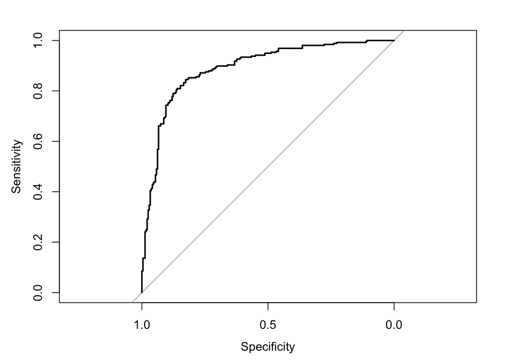

```r
library(pROC)

# For logistic fit
roc_logistic <- roc(test_set$y, p_hat_logistic)
plot(roc_logistic)
```

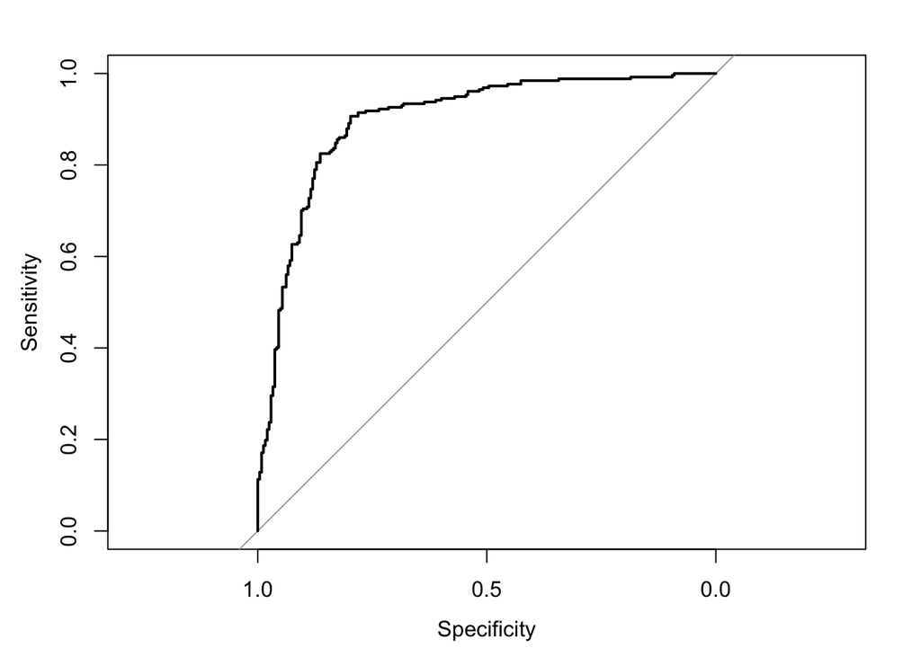

```r
# For naive Bayes fit
roc_nb <- roc(test_set$y, p_hat_nb)
plot(roc_nb)
```

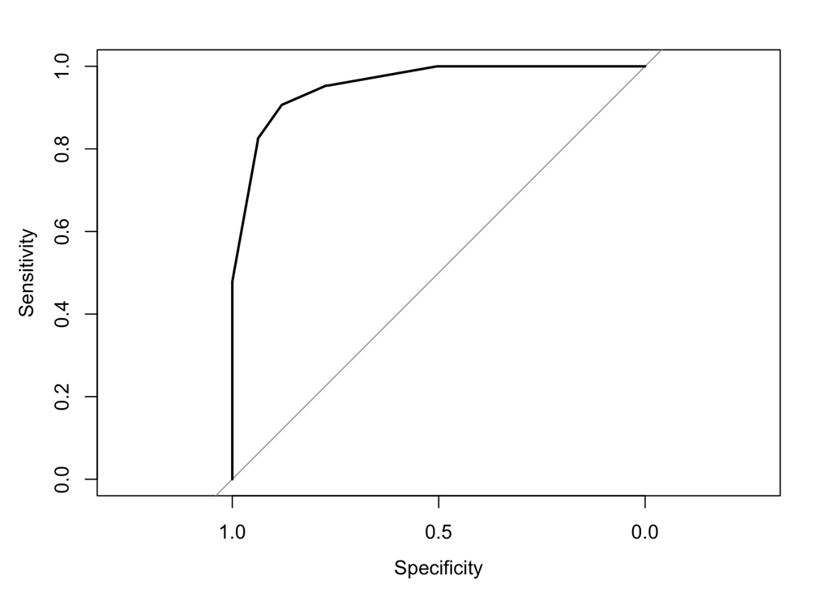

```r
# For knn fit
roc_knn <- roc(test_set$y, p_hat_knn)
plot(roc_knn)
```

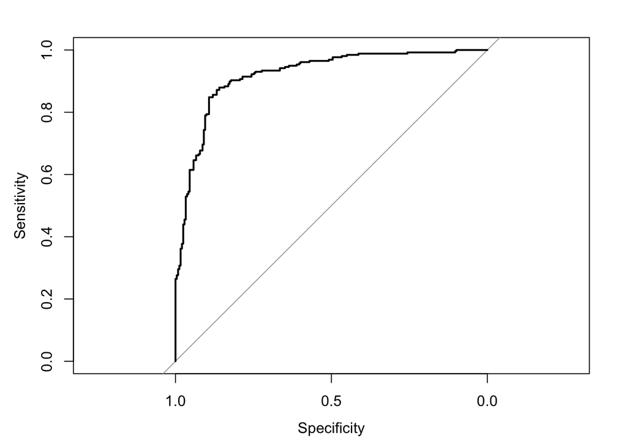

```r
# For qda fit
roc_qda <- roc(test_set$y, p_hat_qda)
plot(roc_qda)
```

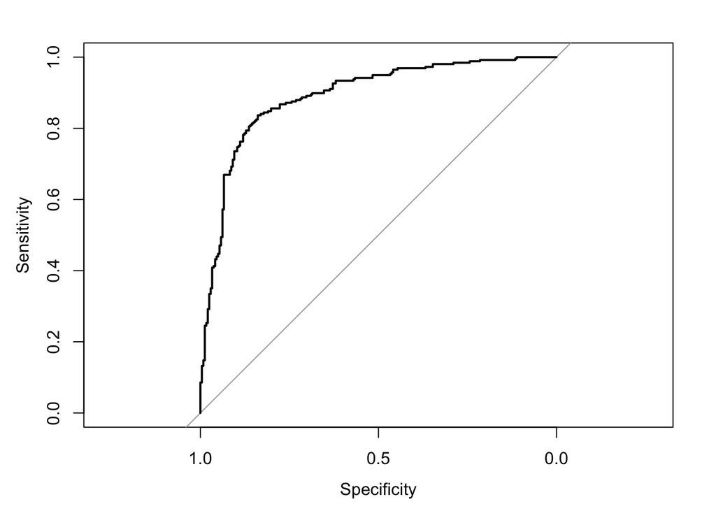

```r
# For lda fit
roc_lda <- roc(test_set$y, p_hat_lda)
plot(roc_lda)
```

Alternatively, a useful function for plotting roc curves is `ggroc` where it is straightforward to compare roc curves within one plot.

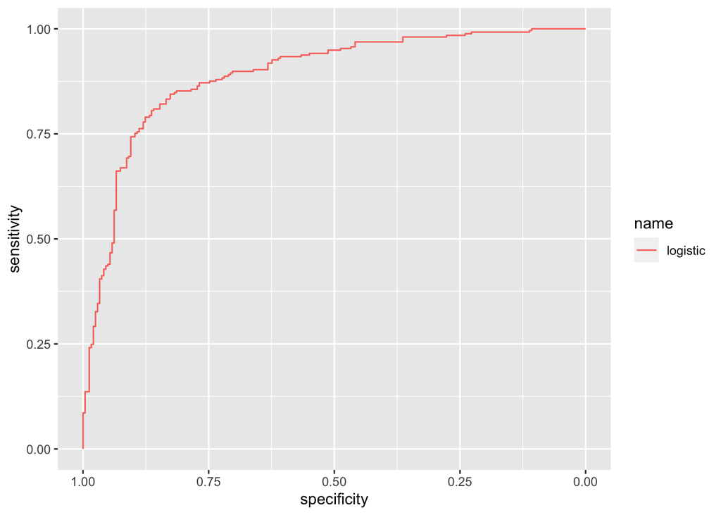

```r
ggroc(list("logistic" = roc_logistic))
```

To add another roc curve:

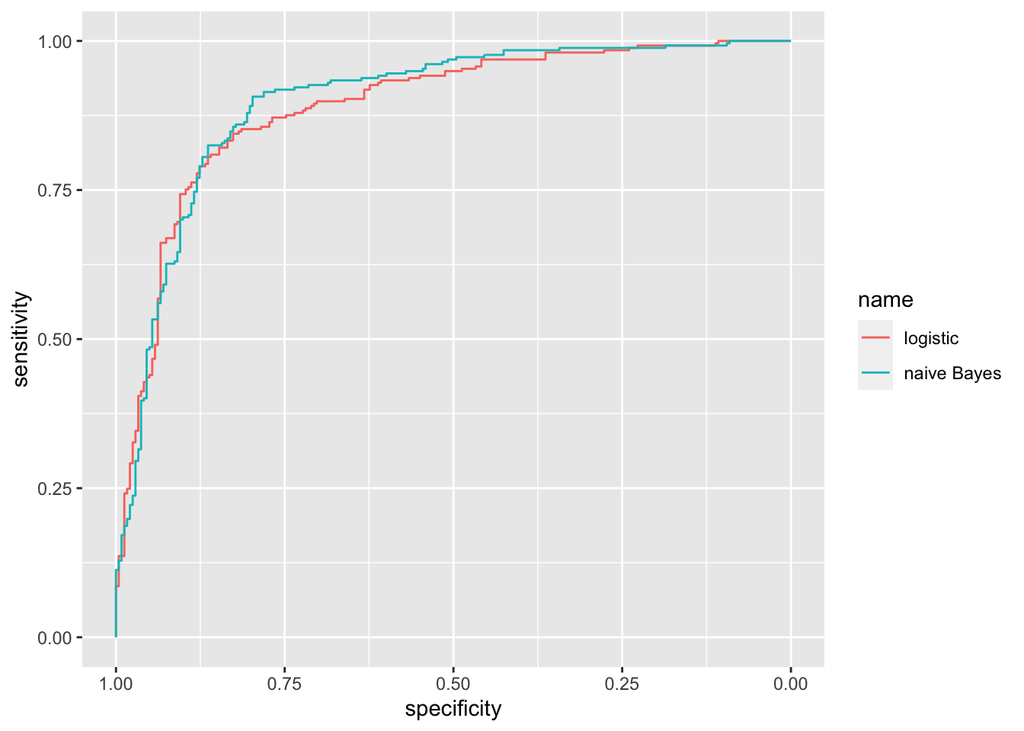

```r
ggroc(list("logistic" = roc_logistic,
           "naive Bayes" = roc_nb))
```

If you’d like to, add a diagonal segment line:

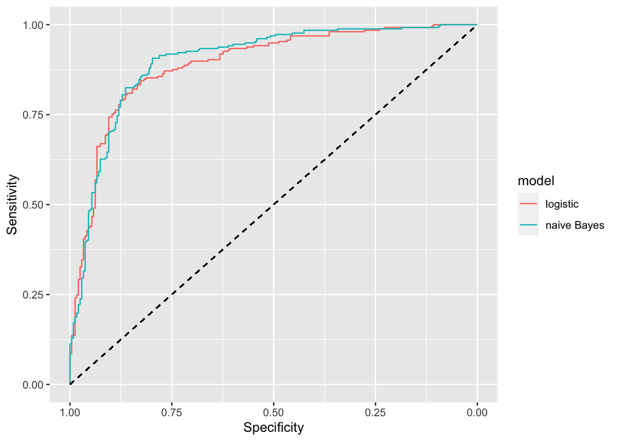

```r
ggroc(list("logistic" = roc_logistic,
           "naive Bayes" = roc_nb)) +
  geom_segment(aes(x = 1, xend = 0, y = 0, yend = 1),
               col = "black",
               linetype = "dashed") +
  labs(x = "Specificity",
       y = "Sensitivity",
       col = "model")
```

Now let’s add knn, qda, lda:

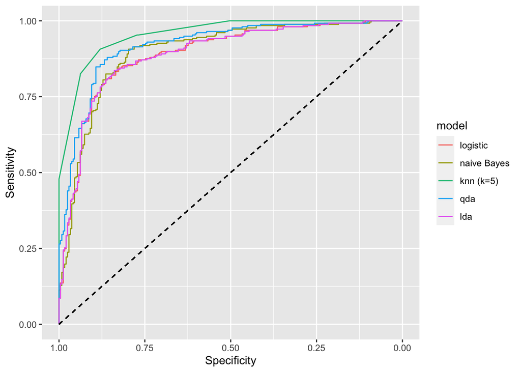

```r
ggroc(list("logistic" = roc_logistic,
           "naive Bayes" = roc_nb,
           "knn (k=5)" = roc_knn,
           "qda" = roc_qda,
           "lda" = roc_lda)) +
  geom_segment(aes(x = 1, xend = 0, y = 0, yend = 1),
               col = "black",
               linetype = "dashed") +
  labs(x = "Specificity",
       y = "Sensitivity",
       col = "model")
```

To summarize the roc curves into a single number, in R we can use `auc()`:

```r
auc(roc_logistic)
```

```
## Area under the curve: 0.8904
```

```r
auc(roc_nb)
```

```
## Area under the curve: 0.899
```

```r
auc(roc_knn)
```

```
## Area under the curve: 0.9566
```

```r
auc(roc_qda)
```

```
## Area under the curve: 0.9202
```

```r
auc(roc_lda)
```

```
## Area under the curve: 0.8908
```

## 3. Today’s lecture

- Midterm due Nov 22 **no free late days**
  - We encourage you to **email** TF / instructor the questions you have about Midterms
  - We have updated the [Google doc](https://docs.google.com/document/d/1YEHtKNvGRRw-YuOZjYD9CIQ9FJUCeDAi/edit) with all of the questions students have asked about midterm so we all have the same information
- Final project teams:
  - Office hours for the following two weeks are (mostly) designated for team meetings
  - Find a time (office hours preferably) to meet with TF (20 minutes) before Nov 17 to review your project (preferably during office hours). For meetings at other times, please email TF or [schedule here](https://calendly.com/lukebenz-gei/20min?month=2023-11).
- Today: review the classification algorithms we learnt and how to built a ML model; three classes
- No lab this Friday, Nov 24
- Homework to be released on Nov 23 (short and simple!)
- HAPPY THANKSGIVING